# ExamenParcial

Bruno Gonzalez 2/10/2019

## EXAMEN PARCIAL

#### 1. Tablas de conteos y bootstrap

En la sección de visualización vimos un ejemplo de tabla de perfiles.

En este ejercicio construiremos intervalos de confianza para una tabla de perfiles usando bootstrap. Usaremos los datos de tomadores de te (del paquete @factominer):

```r
data(tea)
tea <- tea %>%
  as_tibble %>%
  select(how, price, sugar)
```

Nos interesa ver qué personas compran té suelto (`unpacked`), y de qué tipo (`Tea`). Empezamos por ver las proporciones que compran té según su empaque (en bolsita o suelto):

| how | n | % |
| --- | --- | --- |
| tea bag | 170 | 57 |
| tea bag+unpackaged | 94 | 31 |
| unpackaged | 36 | 12 |

La tabla de arriba es poco informativa, buscamos comparar grupos, por ejemplo, queremos investigar si hay diferencias en los patrones de compra (en términos de precio o marca) dependiendo del tipo de té que consumen.

```
## # A tibble: 6 x 4
##   price           `tea bag` `tea bag+unpackaged` unpackaged
##   <fct>               <dbl>                <dbl>      <dbl>
## 1 p_branded              41                   21         14
## 2 p_cheap                 3                    1          3
## 3 p_private label         9                    4          3
## 4 p_unknown               6                    1          0
## 5 p_upscale               8                   20         56
## 6 p_variable             32                   52         25
```

Para facilitar la comparación podemos calcular *perfiles columna*. Comparamos cada una de las columnas con la columna marginal (la tabla de tipo de estilo de té):

| price | tea bag | tea bag+unpackaged | unpackaged | promedio |
| --- | --- | --- | --- | --- |
| p_private label | 0.72 | -0.22 | -0.49 | 5 |
| p_unknown | 0.72 | -0.72 | -1.00 | 4 |
| p_branded | 0.62 | -0.16 | -0.45 | 25 |
| p_cheap | 0.30 | -0.53 | 0.23 | 2 |
| p_variable | -0.12 | 0.44 | -0.31 | 36 |
| p_upscale | -0.71 | -0.28 | 0.98 | 28 |

Leemos esta tabla como sigue: por ejemplo, los compradores de té suelto (`unpacked`) compran té fino (`upscale`) a una tasa casi el doble (0.98) que el promedio.

También podemos graficar como:

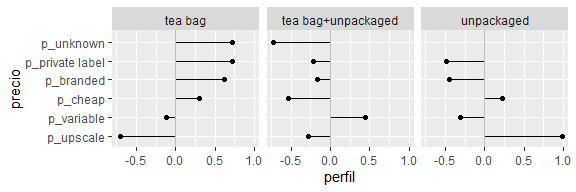

**Observación**: hay dos maneras de construir la columna promedio: tomando los porcentajes sobre todos los datos, o promediando los porcentajes de las columnas como en este ejemplo.

1. Utiliza bootstrap para crear intervalos de confianza sobre los perfiles de la última tabla.

Primero definimos la funcion bootstrap

```r
perfiles_boot <- function(x){
  m <- sample_n(x, size =  300 , replace = TRUE)
  tabla <- m %>%
    count(how, price) %>%
    group_by(how) %>%
    mutate(prop_price = (100 * n / sum(n))) %>%
    group_by(price) %>%
    mutate(prom_prop = mean(prop_price)) %>%
    mutate(perfil = (prop_price / prom_prop - 1) %>% round(2))
  tabla
}
```

Despues corresmos las repeticiones

```r
perfiles_rep <- rerun(10000, perfiles_boot(tea)) %>% bind_rows(.id = 'muestra')
```

Posteriormente calculamos los errores estándard

```r
perfiles_se <- perfiles_rep %>%
  group_by(how, price) %>%
  summarise(se = sd(perfil))
```

Por último calculamos los intervalos

```r
perfiles_int <- tabla %>%
  left_join(perfiles_se) %>%
  mutate(Int_inf = perfil+qnorm(0.025)*se, Int_sup = perfil+qnorm(0.975)*se)
kable(select(perfiles_int, how, price, perfil, Int_inf, Int_sup), digits = 2)
```

| how | price | perfil | Int_inf | Int_sup |
| --- | --- | --- | --- | --- |
| tea bag | p_branded | 0.62 | 0.28 | 0.96 |
| tea bag | p_cheap | 0.30 | -0.37 | 0.97 |
| tea bag | p_private label | 0.72 | 0.12 | 1.32 |
| tea bag | p_unknown | 0.72 | 0.10 | 1.34 |
| tea bag | p_upscale | -0.71 | -0.86 | -0.56 |
| tea bag | p_variable | -0.12 | -0.32 | 0.08 |
| tea bag+unpackaged | p_branded | -0.16 | -0.44 | 0.12 |
| tea bag+unpackaged | p_cheap | -0.53 | -1.09 | 0.03 |
| tea bag+unpackaged | p_private label | -0.22 | -0.75 | 0.31 |
| tea bag+unpackaged | p_unknown | -0.72 | -1.08 | -0.36 |
| tea bag+unpackaged | p_upscale | -0.28 | -0.55 | -0.01 |
| tea bag+unpackaged | p_variable | 0.44 | 0.18 | 0.70 |
| unpackaged | p_branded | -0.45 | -0.82 | -0.08 |
| unpackaged | p_cheap | 0.23 | -0.52 | 0.98 |
| unpackaged | p_private label | -0.49 | -1.05 | 0.07 |
| unpackaged | p_upscale | 0.98 | 0.68 | 1.28 |
| unpackaged | p_variable | -0.31 | -0.63 | 0.01 |

2. Modifica la última gráfica para representar los intervalos de confianza.

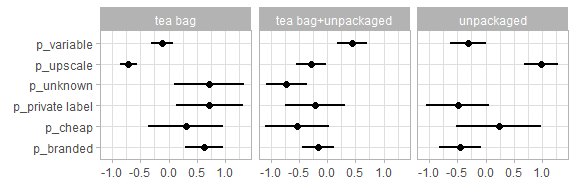

3. Comenta tus observaciones. En la categoria de teabag la mayor tasa de compra son los precios “private label y unknown” que son .72 con un intervalo de confianza entre .10 y 1.34. Lo cual nos indica que este patron de comportamiento es alto en esa categoria porque los usuarios de tea compran mas a estos precios y por otro lado compran a una tasa negativa a precio upscale.

#### 2. Cuantificando el error Monte Carlo

Recordemos que ante la pregunta ¿cuántas muestras bootstrap se necesitan? el error que podemos disminuir al aumentar el número de replicaciones es el error de Monte Carlo, y una manera de cuantificarlo es haciendo bootstrap del bootstrap.

```r
library(estcomp)
# universo
enlace <- enlacep_2013 %>%
    janitor::clean_names() %>%
    mutate(id = 1:n()) %>%
    select(id, cve_ent, turno, tipo, esp_3 = punt_esp_3, esp_6 = punt_esp_6,
        n_eval_3 = alum_eval_3, n_eval_6 = alum_eval_6) %>%
    na.omit() %>%
    filter(esp_3 > 0, esp_6 > 0, n_eval_3 > 0, n_eval_6 > 0, cve_ent == "15")
set.seed(16021)
n <- 300
# muestra
enlace_muestra <- sample_n(enlace, n) %>%
    mutate(clase = "muestra")
```

1. Crea un intervalo del 90% para $\hat{\theta}$ usando los percentiles de la distribución bootstrap, y $B=100$ replicaciones.

Primero creamos la función bootstrap

```r
enlace_boot <- function(x,col){
  col <- enquo(col)
  n <- nrow(x)
  muestra <- sample_n(x,n, replace = TRUE)
  muestra %>%
    select(!!col) %>%
    unlist() %>%
    median()
}
```

Posteriormente se hacen las $B=100$ simulaciones bootstrap.

```r
enlace_rep <- rerun(100, enlace_boot(enlace,esp_3))%>%
  flatten_dbl()
```

Por último, calculamos el intervalos usando los percentiles de la distrubucion bootstrap.

```r
quantile(enlace_rep, c(0.05, 0.95))
```

```
##  5% 95%
## 546 549
```

Primero construimos la función bootstrap de la distribución bootstrap

```r
enlace_boot_boot <- function(x){
  n <- length(x)
  muestra <- sample(x, size = n, replace = TRUE)
  tibble(SE_inf = quantile(muestra, c(0.025,0.975))[1], SE_sup = quantile(muestra, c(0.025,0.975))[2])
}
```

Con la función hacemos las repeticiones

```r
enlace_boot_rep <- rerun(1000,enlace_boot_boot(enlace_rep)) %>%
  bind_rows(.id = 'muestra')
```

- Calcula la desviación estándar de los percentiles (una para cada extremo), esta será tu aproximación al error de Monte Carlo

```r
EMC100 <- map_dbl(enlace_boot_rep, sd)
```

3. ¿Cuál es el error estándar de Monte Carlo con $B = 100, 1000, 10000$ replicaciones para cada extremo del intervalo de percentiles?

Para el caso de $B = 100$

```r
EMC100[2:3]
```

```
##    SE_inf    SE_sup
## 0.2094879 0.1596374
```

Para el caso de $B = 1000$

```r
enlace_rep <- rerun(1000, enlace_boot(enlace,esp_3))%>%flatten_dbl()
enlace_boot_rep <- rerun(1000,enlace_boot_boot(enlace_rep)) %>%
  bind_rows(.id = 'muestra')
map_dbl(enlace_boot_rep, sd)[2:3]
```

```
##    SE_inf    SE_sup
## 0.0000000 0.0890622
```

Para el caso de $B = 10000$

```r
enlace_rep <- rerun(10000, enlace_boot(enlace,esp_3))%>%flatten_dbl()
enlace_boot_rep <- rerun(1000,enlace_boot_boot(enlace_rep)) %>%
  bind_rows(.id = 'muestra')
map_dbl(enlace_boot_rep, sd)[2:3]
```

```
##     SE_inf     SE_sup
## 0.00000000 0.02234949
```

Las corridas muestran la que el error Monte Carlo va disminuyendo conforme se aumentan el número de replicaciones.

#### 3. Cobertura de intervalos de confianza

En este problema realizarás un ejercicio de simulación para comparar la exactitud de distintos intervalos de confianza. Simularás muestras de una distribución Poisson con parámetro $\lambda=2.5$ y el estadístico de interéses $\theta=exp(-2\lambda)$.

Sigue el siguiente proceso:

1. Genera una muestra aleatoria de tamaño $n=60$ con distribución $Poisson(\lambda)$, parámetro $\lambda=2.5$ (en R usa la función `rpois()`).
2. Genera $10,000$ muestras bootstrap y calcula intervalos de confianza del 95% para $\hat{\theta}$ usando 1) el método normal,
   2. percentiles y 3) $BC_a$.

Primero definimos la función del parámetro

```r
poiss_boot <- function(x, ind){
  exp(-2*mean(x[ind]))
}
```

Posteriormente definimos la funcion que genera los intervalos de confianza

```r
poiss_intervalos <- function(n=60) {
  poiss_muestra <- rpois(n,2.5)

  poiss_rep <-  boot(poiss_muestra, poiss_boot,10000)
  poiss_int <-boot.ci(poiss_rep, type = c("norm", "perc", "bca"))

  data.frame(metodo = c('normal','percentil','BCa'),
             theta = poiss_int$t0,
             inferior = c(poiss_int$normal[2],poiss_int$percent[4],poiss_int$bca[4]),
             superior = c(poiss_int$normal[3],poiss_int$percent[5],poiss_int$bca[5]))
}
```

Finalmente, los intervalos son:

```r
poiss_intervalos() %>%
  kable(digits = 4)
```

| metodo | theta | inferior | superior |
| --- | --- | --- | --- |
| normal | 0.005 | 0.0003 | 0.0089 |
| percentil | 0.005 | 0.0023 | 0.0107 |
| BCa | 0.005 | 0.0022 | 0.0101 |

3. Revisa si el intervalo de confianza contiene el verdadero valor del parámetro ($\theta=exp(-2\cdot2.5)$), en caso de que no lo contenga registra si falló por la izquierda o falló por la derecha.

Los tres intervalos de confianza contienen el verdadero valor del parámetro 0.0067379

1. Repite el proceso descrito 1000 veces y llena la siguiente tabla:

```r
poiss_rep_int <- rerun(1000, poiss_intervalos()) %>% bind_rows(.id = 'muestra')
```

Posteriormente calculamos los fallos y combertura

```r
poiss_rep_int <- poiss_rep_int %>%
  mutate(fallo_izquierda = exp(-2*2.5)<inferior,
         fallo_derecha = exp(-2*2.5)>superior,
         Longitud = superior-inferior)
```

Así tenemos la siguiente tabla:

```r
poiss_rep_int %>%
  group_by(metodo) %>%
  summarise(P_fallo_izquierda = sum(fallo_izquierda)/n(),
            P_fallo_derecha = sum(fallo_derecha)/n(),
            Cobertura = 1 - P_fallo_izquierda - P_fallo_derecha,
            Longitud_promedio = mean(Longitud)) %>%
  kable()
```

| metodo | P_fallo_izquierda | P_fallo_derecha | Cobertura | Longitud_promedio |
| --- | --- | --- | --- | --- |
| BCa | 0.021 | 0.022 | 0.957 | 0.0117646 |
| normal | 0.000 | 0.058 | 0.942 | 0.0126198 |
| percentil | 0.027 | 0.014 | 0.959 | 0.0123914 |

La columna cobertura es una estimación de la cobertura del intervalo basada en las simulaciones, para calcularla simplemente escribe el porcentaje de los intervalos que incluyeron el verdadero valor del parámetro. La longitud promedio es la longitud promedio de los intervalos de confianza bajo cada método.

2. Realiza una gráfica de páneles, en cada panel mostrarás los resultados de uno de los métodos (normal, percentiles y BC_a), en el vertical graficarás los límites de los intervalos.

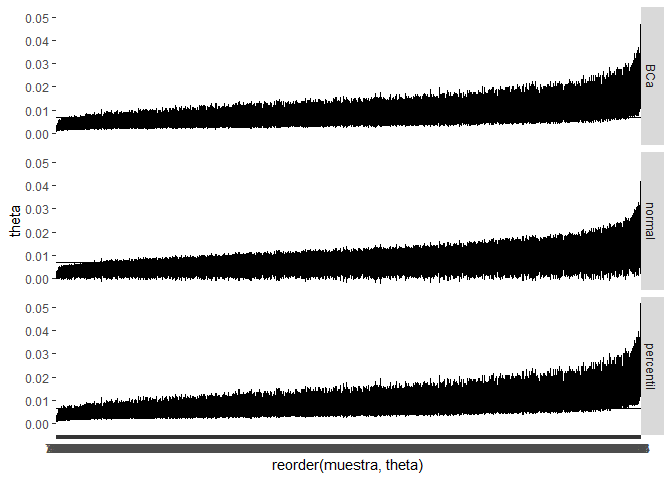

```r
  ggplot(poiss_rep_int) +
    geom_pointrange(aes(x = reorder(muestra,theta),
                        ymin = inferior,
                        y=theta,
                        ymax = superior),
                    size=0.2) +
    geom_hline(yintercept = exp(-2.5*2)) +
    facet_grid(metodo~.)
```

3. Repite los incisos a) y b) seleccionando muestras de tamaño $300$.

Primero hacemos las repeticiones con el tamano de muestra 300.

```r
poiss_rep_int_300 <- rerun(1000, poiss_intervalos(300))%>%
  bind_rows(.id = 'muestra') %>%
  mutate(fallo_izquierda = exp(-2*2.5)<inferior,
         fallo_derecha = exp(-2*2.5)>superior,
         Longitud = superior-inferior)
```

Así obtenemos la siguiente tabla:

```r
poiss_rep_int_300 %>%
  group_by(metodo) %>%
  summarise(P_fallo_izquierda = sum(fallo_izquierda)/n(),
            P_fallo_derecha = sum(fallo_derecha)/n(),
            Cobertura = 1 - P_fallo_izquierda - P_fallo_derecha,
            Longitud_promedio = mean(Longitud))%>%
  kable()
```

| metodo | P_fallo_izquierda | P_fallo_derecha | Cobertura | Longitud_promedio |
| --- | --- | --- | --- | --- |
| BCa | 0.020 | 0.030 | 0.950 | 0.0049177 |
| normal | 0.005 | 0.050 | 0.945 | 0.0049909 |
| percentil | 0.026 | 0.027 | 0.947 | 0.0049767 |

Y la siguiente gráfica:

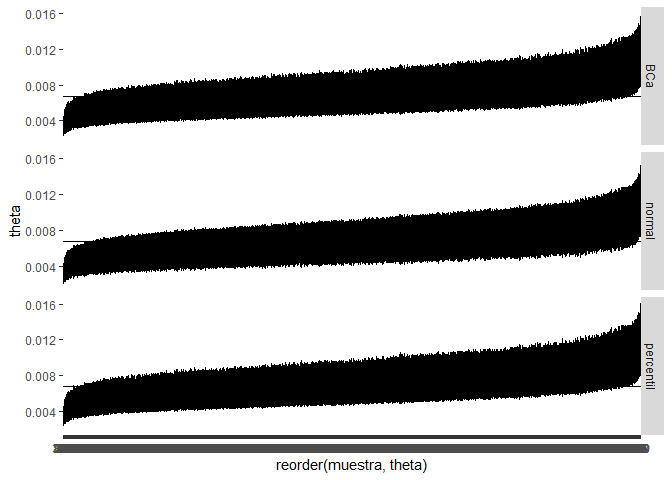

```r
  ggplot(poiss_rep_int_300) +
    geom_pointrange(aes(x = reorder(muestra,theta),
                        ymin = inferior,
                        y=theta,
                        ymax = superior),
                    size=0.2) +
    geom_hline(yintercept = exp(-2.5*2)) +
    facet_grid(metodo~.)
```

#### 4. Cobertura en la práctica

En el caso del conteo rápido es posible evaluar la cobertura del intervalo de confianza bootstrap usando los resultados de elecciones pasadas, para ello usaremos los resultados de las elecciones 2006 (datos `election_2006` del paquete `estcomp`) repetirás los siguientes dos pasos 100 veces (asegurate de que tu ejercicio de simulación sea replicable):

1. Selecciona una muestra estratificada de `election_2006` usando los tamaños de muestra que indica la tabla `strata_sample_2006` (donde `n` era el tamaño de muestra por estrato y `N` es el número de casillas en el mismo).

Para elegir la muestra se define la siguiente funcion:

```r
muestra_2006 <- function(df=election_2006){
  df %>%
    select(stratum,pri_pvem,pan,panal,prd_pt_conv,psd,otros) %>%
    left_join(strata_sample_2006) %>%
    split(.$stratum) %>%
    map_df(~sample_n(., size=first(.$n)))
}
```

2. Utiliza estimador de razón y bootstrap para construir intervalos de confianza para todos los candidatos.

Primer construimos una función para obtener el estimador de razón:

```r
estimador_razon <- function(df){
  df %>%
    pivot_longer(pri_pvem:otros, names_to = 'partido', values_to = 'votos') %>%
    mutate(v_total = N*votos/n, total = sum(v_total)) %>%
    group_by(partido) %>%
    summarise(p=sum(v_total)/mean(total)) %>%
    pivot_wider(names_from = partido, values_from = p)
}
```

Ayudándonos de esta función, se construye una fución para obtener el estimador bootstrap:

```r
elecciones_boot <- function(df=muestra){
  muestra_boot <- df %>%
    group_by(stratum) %>%
    sample_frac(size = 1, replace = TRUE) %>%
    ungroup()
    estimador_razon(muestra_boot)
}
```

Asi, podemos obtener una distribucion bootstrap

```r
muestra1 <- muestra_2006()
elecciones_muestras_boot <- rerun(1000,elecciones_boot(muestra1)) %>% bind_rows()
```

Y con esto el intervalo de confianza:

```r
elecciones_pi <- estimador_razon(muestra1)
elecciones_es <- map_dbl(elecciones_muestras_boot,sd)
rbind(razon = elecciones_pi) %>%
  rbind(inferior = elecciones_pi + elecciones_es*qnorm(0.025)) %>%
  rbind(superior =elecciones_pi + elecciones_es*qnorm(0.975)) %>%
  t()
```

```
##                   razon    inferior   superior
## otros       0.028630387 0.028219566 0.02904121
## pan         0.358575842 0.355941574 0.36121011
## panal       0.009958717 0.009630307 0.01028713
## prd_pt_conv 0.352538506 0.350208144 0.35486887
## pri_pvem    0.223109441 0.221150183 0.22506870
## psd         0.027187107 0.026838376 0.02753584
```

Evalúa la cobertura del intervalo para cada candidato a lo largo de las 100 muestras, presenta los resultados en una tabla que incluya la longitud media de los intervalos y la cobertura observada.

Para hacer las 100 repeticiones, definimos la funcion siguiente:

```r
elecciones_boot_rep <- function(df=election_2006){
  muestra <- muestra_2006(df)
  razon_pi <- estimador_razon(muestra)
  muestras_boot <- rerun(1000,elecciones_boot(muestra)) %>% bind_rows()
  error <- map_dbl(muestras_boot,sd)

  rbind(razon=razon_pi) %>%
    rbind(inferior = razon_pi+error*qnorm(0.025)) %>%
    rbind(superior = razon_pi+error*qnorm(0.975)) %>%
    t() %>%
    as.data.frame() %>%
    rownames_to_column('partido')

}
```

Con esta funcion corremos las 100 repeticiones:

```r
elecciones_repeticiones <- rerun(100, elecciones_boot_rep()) %>%
  bind_rows(.id = 'repeticion')
```

Los resultados se presentan en la siguiente tabla:

```r
elecciones_repeticiones %>%
mutate(fallo_izquierda = razon<inferior,
       fallo_derecha = superior<razon,
       longitud = superior-inferior) %>%
group_by(partido) %>%
summarise(fallo_izquierda = sum(fallo_izquierda)/n(),
          fallo_derecha = sum(fallo_derecha)/n(),
          cobertura = 1 - fallo_izquierda - fallo_derecha,
          longitud = mean(longitud)) %>%
  kable(round = 4)
```

| partido | fallo_izquierda | fallo_derecha | cobertura | longitud |
| --- | --- | --- | --- | --- |
| otros | 0 | 0 | 1 | 0.0010367 |
| pan | 0 | 0 | 1 | 0.0052655 |
| panal | 0 | 0 | 1 | 0.0005689 |
| prd_pt_conv | 0 | 0 | 1 | 0.0046776 |
| pri_pvem | 0 | 0 | 1 | 0.0039224 |
| psd | 0 | 0 | 1 | 0.0006787 |

**Opicional (punto extra):** Las muestras con las que se estima en el conteo rápido nunca llegan completas, y los faltantes suelen presentar patrones, por ejemplo, las casillas en las zonas rurales tienen mayor probabilidad de no llegar. Repite el ejercicio de simulación de arriba añadiendo un paso de casillas faltantes, lo que debes hacer es que una vez simulada una muestra *completa* cada casilla se censura de acuerdo a cierta probabilidad (tu la eliges como desees), y esta probabilidad puede depender, por ejemplo, de si la casilla es rural o urbana o quizá puede variar por estado. Elige uno (o más) procedimiento(s) de censura de casillas y evalúa la cobertura de los intervalos en este(os) escenario(s). Puedes explorar las variables disponibles viendo la documentación de los datos (`?election_2006`).

#### 5. Simulación de variables aleatorias

Recuerda que una variable aleatoria $X$ tiene una distribución geométrica con parámetro $p$ si
$$p_X(i) = P(X=i)=pq^{i-1}$$
para $i=1,2,...$ y donde $q=1-p$.

Notemos que
$$\sum_{i=1}^{j-1}P(X=i)=1-P(X\geq j-1)$$
$$=1 - q^{j-1}$$
para $j\geq 1$. por lo que podemos generar un valor de $X$ generando un número aleatorio $U$ y seleccionando $j$ tal que
$$1-q^{j-1} \leq U \leq 1-q^j$$

Esto es, podemos definir $X$ como:
$$X=min\{j : (1-p)^j < 1-U\}$$
usando que el logaritmo es una función monótona (i.e. $a<b$ implica $log(a)<log(b)$) obtenemos que podemos expresar $X$ como
$$X=min\big\{j : j \cdot log(q) < log(1-U)\big\}$$
$$=min\big\{j : j > log(U)/log(q)\big\}$$
entonces
$$X= int\bigg(\frac{log(U)}{log(q)}\bigg)+1$$

es geométrica con parámetro $p$.

Ahora, sea $X$ el número de lanzamientos de una moneda que se requieren para alcanzar $r$ éxitos (soles) cuando cada lanzamiento es independiente, $X$ tiene una distribución binomial negativa.

Una variable aleatoria $X$ tiene distribución binomial negativa con parámetros $(r,p)$ donde $r$ es un entero positivo y $0<p<r$ si
$$P(X=j)=\frac{(j-1)!}{(j-r)!(r-1)!}p^r(1-p)^{j-r}.$$

1. Recuerda la distribución geométrica ¿cuál es a relación entre la variable aleatoria binomial negativa y la geométrica?

La distribución geometrica es un caso particular de la binomian negativa cuando $r=1$, es decir, cuando solo se quiere obtener el número de lanzamientos antes del primer exito.

2. Utiliza el procedimiento descrito para generar observaciones de una variable aleatoria con distribución geométrica y la relación entre la geométrica y la binomial negativa para generar simulaciones de una variable aleatoria con distribución binomial negativa (parámetro p = 0.7, r = 20). Utiliza la semilla 341285 y reporta las primeras 10 simulaciones obtenidas.

Para el caso de la geometrica tenemos:

```r
set.seed(341285)
sim_geometrica <- function(p, n=1){
  U <- runif(n)
  q <- (1-p)
  as.integer(log(U)/log(q))+1
}

sim_geometrica(0.7,10)
```

```
##  [1] 1 1 1 1 2 2 1 1 2 1
```

Para el caso de la binomial negativa tenemos:

```r
sim_binn <- function(p,r){
  sum(sim_geometrica(p,n=r))
}

rerun(10,sim_binn(0.7,20)) %>% flatten_dbl()
```

```
##  [1] 25 28 28 31 29 35 34 30 29 30
```

3. Verifica la relación
   $$p_{j+1}=\frac{j(1-p)}{j+1-r}p_j$$

y úsala para generar un nuevo algoritmo de simulación, vuelve a definir la semilla y reporta las primeras 10 simulaciones.

$$\frac{p_{j +1}}{p_j} = \frac{\frac{j!}{(j+1-r)!(r-1)!}p^r(1-p)^{j+1-r}}{\frac{(j-1)!}{(j-r)!(r-1)!}p^r(1-p)^{j-r}}= \frac{j(1 - p) }{j + 1 - r}.$$

```r
set.seed(341285)
sim_binn_rec <- function(p,r){
  U <- runif(1)
  i <- r
  f <- p^r
  P <- f
  while(U>=P){
    f <- i*(1-p)*f/(i+1-r)
    P <- P+f
    i <- i+1
  }
  i
}

rerun(10, sim_binn_rec(0.7,20)) %>% flatten_dbl()
```

```
##  [1] 30 29 31 30 26 25 33 27 25 40
```

4. Realiza 10,000 simulaciones usando cada uno de los algoritmos y compara el tiempo de ejecución (puedes usar la función `system.time()`.

```r
system.time(rerun(10000, sim_binn(0.7,20)))
```

```
##    user  system elapsed
##    0.06    0.00    0.06
```

```r
system.time(rerun(10000, sim_binn_rec(0.7,20)))
```

```
##    user  system elapsed
##    0.07    0.00    0.06
```

5. Genera un histogrma para cada algoritmo (usa 1000 simulaciones) y comparalo con la distribución construida usando la función de R *dnbinom*.